# The Bayesian Appreciation of Wine and Teak

I came across the paper “The Analysis of Experimental Data: The Appreciation of Tea and Wine” by Dennis Lindley which goes over some problematic aspects of Fisher’s famous tea cup experiment. The experiment is as follows: Muriel Bristol, a friend of Fisher, claims that she can distinguish between tea where the milk has been added before the tea, and tea where the milk has been added after. Now everyone knows someone (or is this someone) that claims to be able to distinguish between Coca Cola and Pepsi, tea made with soft and with hard water (that’s me) or cheap and expensive wine. So you’ve probably found yourself already in some experimental setup in which you tried to test someone’s skill to discriminate. Setups on how to test vary, but one possible is to give pairs of cups of tea (we stick with the tea for now), one with the milk added before and the other with the milk added after. For each pair, note if the tested person could discriminate correctly or not, that is was she right $R$ or wrong $W$. Fisher gave Lady Bristol 6 pairs of cups of tea and she got the following result: $RRRRRW$, that is, only the last pair was wrong. Does this mean she has discriminatory power or not? Now Fisher proceeds as follows: He considers the null hypothesis, that is, the hypothesis that she cannot distinguish between the two and just guesses. Under that hypothesis, with probability $p=\frac{1}{2}$, she guesses correctly. In that case, the sequence $RRRRRW$ has probability $Pr(RRRRRW) = (\frac{1}{2})^6 = \frac{1}{64}$. But actually, every other sequence has the same probability. Instead, we’re interested in the probability of guessing only one pair wrong, that is, all permutations of $RRRRRW$. There are 6 such permutations, hence $Pr(\text{ 1 pair wrong}) = 6 \cdot 0.5^6 = \frac{6}{64} = 0.094$. This still does not quite work. In the case of just guessing, the most probable outcome would be to have one half of pairs correct, the other half wrong. But this is not quite the outcome we expect to see most of the time, most of the time, we expect to see *around half* of pairs correct. So instead of considering the probability of getting 5 of 6 pairs correct when just guessing, we now consider the probability of getting 5 or more out of 6 pairs correct. That is, the probability of all results as, or more, extreme than the result observed. For 6 observations, this is the probability of getting only wrong or no wrong: $Pr(\text{ 1 wrong }) + Pr(\text{ no wrong }) = \frac{7}{64} = 0.109$. Since someone in science at some point decided, that probabilities more than 5% are not enough to reject the null hypothesis, i.e. the resulsts are not significant. That’s it Lady Bristol, you can’t distinguish tea with milk from milk with tea.

Somehow, this is not very satisfactory. Let’s try the Bayesian way instead.

As a Bayesianist, I don’t just consider the null hypothesis ($p=\frac{1}{2}$ in this example) but all alternative hypotheses (that I consider plausible) and compare which hypothesis has the highest probability. For any $p$, the result $RRRRRW$ has probability $p^5(1-p)$. This is our likelihood function.

Now I personally, do believe that it is possible to distinguish tea made with hard water from tea made with soft water. I don’t like tea with milk, so I don’t have much of an opinion if some people can distinguish it or not. I do have my doubts though about distinguishing cheap from expensive wine. At least in my friend circle, I don’t think anyone has such good taste buds. So i would choose my priors as follows:

```r
p <- seq(0,1,length.out = 200)
prior_tea_w <- ifelse(p < 0.5, 0, 48*(1-p)*(p-0.5) )
prior_tea_m <- ifelse(p < 0.5, 0, 2 )
prior_wine <- ifelse(p<0.5, 0, - 8*p + 8)
par(mfrow=c(1,3))
plot(p, prior_tea_w, "l", main="Tea with hard water")
plot(p, prior_tea_m, "l", main="Tea with milk")
```

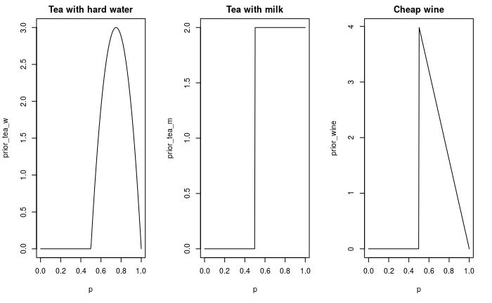

```r
plot(p, prior_wine, "l", main="Cheap wine")
```

These are really just my own priors, you might have very different opinions and beliefs about wine and tea tasting. With these priors, we can go on to compute the posterior probability, using Bayes theorem. That is, multiply the probability of the prior with the likelihood and then scale to 1.

```r
compute_posterior <- function(w, n, prior) {
  num_pts = length(prior)
  p_grid = seq(from=0, to=1, length.out=num_pts)
  likelihood <- dbinom(w, size=n, prob=p_grid)

  # compute product of likelihood and prior (unstandardized posterior)
  unstd.posterior <- likelihood * prior

  # standardize posterior
  posterior <- num_pts * unstd.posterior / sum(unstd.posterior)
}
p <- seq(from=0,to=1, length.out = length(prior_tea_w))
post_tea_w <- compute_posterior(w=5, n=6, prior=prior_tea_w)
post_tea_m <- compute_posterior(w=5, n=6, prior=prior_tea_m)
post_wine <- compute_posterior(w=5, n=6, prior=prior_wine)
par(mfrow=c(1,3))
plot(p, post_tea_w, type="l", ylim=c(0,4))
#lines(p, prior_tea_w)
mtext("Tea with hard water")
```

```r
plot(p, post_tea_m, type="l", ylim=c(0,4))
mtext("Tea with milk")
```

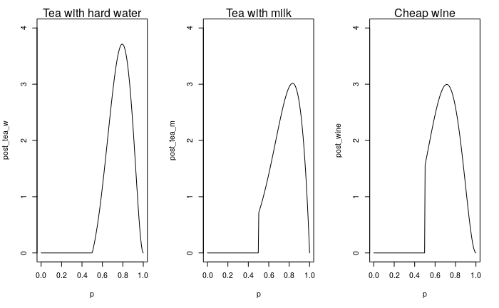

```r
plot(p, post_wine, type="l", ylim=c(0,4))
mtext("Cheap wine")
```

[output not shown]

[output not shown]

[output not shown]